# Fitness_Equipment_Supplier_Customer_Segmentation

```python
def plt_most10_count_plot(ax_, df_, type_var_, var_, type_, title_, independant_label_, dependant_label_, unit_='', highlight_num=None, highlight_color='#DC3535', orientation_='v'):
  list_most10 = df_.loc[df_[type_var_]==type_, var_].value_counts().iloc[:10].index
  df_ = df_.loc[(df_[type_var_]==type_) & df_[var_].isin(list_most10), [var_]]

  if not highlight_num:
    list_highlight = df_[var_].value_counts()/df_[var_].count()
    list_highlight = list_highlight[list_highlight > 0.1]
    highlight_num = len(list_highlight)

  custom_palette = [highlight_color for i in range(highlight_num)] + ['grey' for i in range(10-highlight_num)]
  if orientation_ == 'v':
    sns.countplot(data=df_, x=var_, order=list_most10, ax=ax_,
                      palette = custom_palette)

    plt.sca(ax_)
    plt.xlabel(independant_label_)
    plt.ylabel(dependant_label_)

    plt.tick_params(
      axis='y',          # changes apply to the y-axis
      which='both',      # both major and minor ticks are affected
      left=False,      # ticks along the left edge are off
      right=False,         # ticks along the right edge are off
      labelleft=False) # labels along the left edge are off

    labels = []
    for label in ax_.get_xticklabels():
        text = label.get_text()
        labels.append(textwrap.fill(text, width=10,
                      break_long_words=False))
    ax_.set_xticklabels(labels, rotation=60)

    bar_labels=[]
    for container in ax_.containers:
      for rect in container:
        # Rectangle widths are already integer-valued but are floating
        # type, so it helps to remove the trailing decimal point and 0 by
        # converting width to int type

        # Shift the text to the left side of the right edge
        yloc = 4
        # White on magenta
        clr = 'white'
        align = 'bottom'
        rotation_ = 90

        count_ = rect.get_height()
        pct_ = int(count_*100/df_[var_].count())
        pct_unit = f'({pct_}%) {unit_}'

        label_text = '' if not count_ else round(count_) if count_ > 0 and count_ < 1000 else f'{count_/1000: .1f} k'
        label_text = f'{label_text} {pct_unit}' if label_text and count_/container[0].get_height() > 0.05+0.022*len(pct_unit) else label_text if count_/container[0].get_height() > 0.05 else ''

        size_ = 12 if count_/container[0].get_height() > 0.1 else 9 if count_/container[0].get_height() > 0.06 else 8 if count_/container[0].get_height() > 0.055 else 7

        xloc = rect.get_x() + rect.get_width() / 2
        ax_.annotate(label_text, xy=(xloc, 0), xytext=(0, yloc),
                            textcoords="offset points", size=size_,
                            ha='center', va=align, rotation=rotation_,
                            color=clr, clip_on=True)

  else:
    sns.countplot(data=df_, y=var_, order=list_most10, ax=ax_,
                      palette = custom_palette)
    plt.sca(ax_)
    plt.xlabel(dependant_label_)
    plt.ylabel(independant_label_)

    plt.tick_params(
      axis='x',          # changes apply to the x-axis
      which='both',      # both major and minor ticks are affected
      bottom=False,      # ticks along the bottom edge are off
      top=False,         # ticks along the top edge are off
      labelbottom=False) # labels along the bottom edge are off

    labels = []
    for label in ax_.get_yticklabels():
        text = label.get_text()
        labels.append(textwrap.fill(text, width=15,
                      break_long_words=False))
    ax_.set_yticklabels(labels, rotation=0)

    bar_labels=[]
    for container in ax_.containers:
      for rect in container:
        # Rectangle widths are already integer-valued but are floating
        # type, so it helps to remove the trailing decimal point and 0 by
        # converting width to int type

        # Shift the text to the left side of the right edge
        xloc = 2
        # White on magenta
        clr = 'white'
        align = 'left'

        count_ = rect.get_width()
        pct_ = int(count_*100/df_[var_].count())
        pct_unit = f'({pct_}%) {unit_}'

        label_text = '' if not count_ else round(count_) if count_ > 0 and count_ < 1000 else f'{count_/1000: .1f} k'
        label_text = f'{label_text} {pct_unit}' if label_text and count_/container[0].get_width() > 0.05+0.022*len(pct_unit) else label_text if count_/container[0].get_width() > 0.05 else ''

        size_ = 12 if count_/container[0].get_width() > 0.1 else 9 if count_/container[0].get_width() > 0.06 else 8 if count_/container[0].get_width() > 0.055 else 7

        # Center the text vertically in the bar
        yloc = rect.get_y() + rect.get_height() / 2
        ax_.annotate(label_text, xy=(0, yloc), xytext=(xloc, 0),
                            textcoords="offset points", size=size_,
                            ha=align, va='center',
                            color=clr, clip_on=True)

  sns.despine(left=True, bottom=True, ax=ax_)

  plt.title(title_, size=16, color='grey')
  plt.xticks(size=12)
  plt.yticks(size=12)

  ax_.spines['left'].set_color('grey')
  ax_.spines['bottom'].set_color('grey')

  ax_.figure.set_size_inches(16,8)
  ax_.figure.subplots_adjust(top=0.81,right=0.86)

  return plt
```

```python
def product_wise_distribution(df_, var_, box_major=[None, None, None], box_minor=[None, None, None]):
  fig = plt.figure(figsize=(16,16))

  ax1 = plt.subplot(2, 3, 1)
  ax4 = plt.subplot(2, 3, 4, sharex=ax1)
  ax2 = plt.subplot(2, 3, 2)
  ax5 = plt.subplot(2, 3, 5, sharex=ax2)
  ax3 = plt.subplot(2, 3, 3)
  ax6 = plt.subplot(2, 3, 6, sharex=ax3)

  plot_hist_custom(ax_=ax1, df_=df.loc[df['Product']=='KP281'], var_=var_, title_=f'Distribution of {var_} for KP281', scale_x_major=box_major[0], scale_x_minor=box_minor[0], color_='#18978F')
  plot_box_custom(ax_=ax4, df_=df.loc[df['Product']=='KP281'], var_=var_, xlabel_=var_, scale_x_major=box_major[0], scale_x_minor=box_minor[0], color_='#18978F')

  plot_hist_custom(ax_=ax2, df_=df.loc[df['Product']=='KP481'], var_=var_, title_=f'Distribution of {var_} for KP481', scale_x_major=box_major[1], scale_x_minor=box_minor[1], color_='#DC3535')
  plot_box_custom(ax_=ax5, df_=df.loc[df['Product']=='KP481'], var_=var_, xlabel_=var_, scale_x_major=box_major[1], scale_x_minor=box_minor[1], color_='#DC3535')

  plot_hist_custom(ax_=ax3, df_=df.loc[df['Product']=='KP781'], var_=var_, title_=f'Distribution of {var_} for KP781', scale_x_major=box_major[2], scale_x_minor=box_minor[2], color_='#3A5BA0')
  plot_box_custom(ax_=ax6, df_=df.loc[df['Product']=='KP781'], var_=var_, xlabel_=var_, scale_x_major=box_major[2], scale_x_minor=box_minor[2], color_='#3A5BA0')

  plt.subplots_adjust(hspace = 0, wspace=0.25)

  plt.show()
```

```python
def plot_heatmap(ax_, df_, var_, size=None):
  ax = sns.heatmap(pd.crosstab(index=df_[var_], columns=df_['Product'], dropna=False, normalize='index').round(2).T, ax=ax_, annot=True, cbar=False, cmap=sns.cubehelix_palette(as_cmap=True))
  plt.title('Conditional Probabilities', size=16, color='grey')
  ax_.figure.set_size_inches(size)
```

```python
def product_wise_plots(df_, var_, main_title, xlablel_, title_, highligh_num = [None, None, None], box_major=[None, None, None], box_minor=[None, None, None]):
  fig, axd = plt.subplot_mosaic([['upper', 'upper', 'upper'],
                                ['lower left', 'lower middle', 'lower right']])
  ax1 = axd['upper']
  ax2 = axd['lower left']
  ax3 = axd['lower middle']
  ax4 = axd['lower right']

  plt_dist_plot(ax_=ax1, df_=df_, type_var_='Product', var_=var_, title_=main_title, xlabel_=xlablel_, ylabel_='Density')
  plt_most10_count_plot(ax_=ax2, df_=df_, type_var_ = 'Product', var_=var_, type_='KP281', title_=title_, independant_label_='', dependant_label_='', unit_='KP281s', highlight_num=highligh_num[0], highlight_color='#18978F', orientation_='h')
  plt_most10_count_plot(ax_=ax3, df_=df_, type_var_ = 'Product', var_=var_, type_='KP481', title_=title_, independant_label_='', dependant_label_='', unit_='KP481s', highlight_num=highligh_num[1], highlight_color='#DC3535', orientation_='h')
  plt_most10_count_plot(ax_=ax4, df_=df_, type_var_ = 'Product', var_=var_, type_='KP781', title_=title_, independant_label_='', dependant_label_='', unit_='KP781s', highlight_num=highligh_num[2], highlight_color='#3A5BA0', orientation_='h')

  fig.set_size_inches(16,16)
  plt.subplots_adjust(hspace = 0.25, wspace=0.25)

  plt.show()

  product_wise_distribution(df_=df_, var_=var_, box_major=box_major, box_minor=box_minor)

  plot_heatmap(ax_=plt.subplot(), df_=df, var_=var_, size=(16, 6))
```

## Product wise customer segmentation for each customer characteristic

## Gender and Marital Status

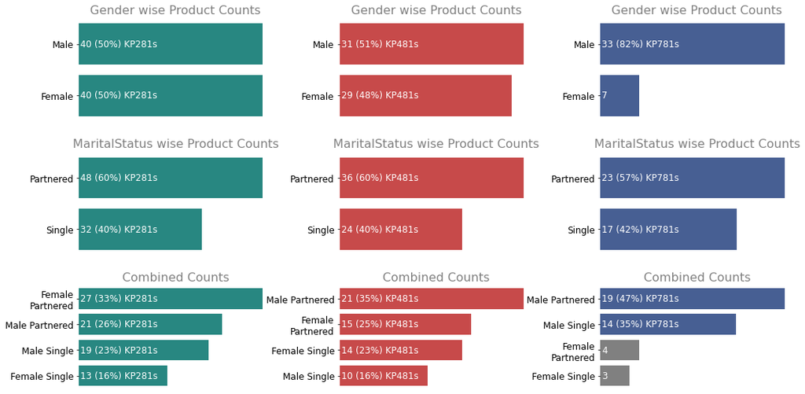

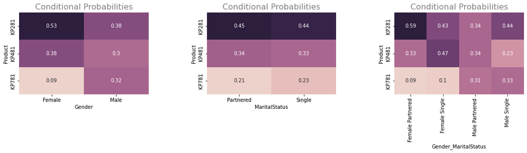

```python
mosaic = '''123
            456
            789'''
fig, axd = plt.subplot_mosaic(mosaic)
ax1 = axd['1']
ax2 = axd['2']
ax3 = axd['3']
ax4 = axd['4']
ax5 = axd['5']
ax6 = axd['6']
ax7 = axd['7']
ax8 = axd['8']
ax9 = axd['9']

plt_most10_count_plot(ax_=ax1, df_=df, type_var_ = 'Product', var_='Gender', type_='KP281', title_='Gender wise Product Counts', independant_label_='', dependant_label_='', unit_='KP281s', highlight_num=None, highlight_color='#18978F', orientation_='h')
plt_most10_count_plot(ax_=ax2, df_=df, type_var_ = 'Product', var_='Gender', type_='KP481', title_='Gender wise Product Counts', independant_label_='', dependant_label_='', unit_='KP481s', highlight_num=None, highlight_color='#DC3535', orientation_='h')
plt_most10_count_plot(ax_=ax3, df_=df, type_var_ = 'Product', var_='Gender', type_='KP781', title_='Gender wise Product Counts', independant_label_='', dependant_label_='', unit_='KP781s', highlight_num=None, highlight_color='#3A5BA0', orientation_='h')

plt_most10_count_plot(ax_=ax4, df_=df, type_var_ = 'Product', var_='MaritalStatus', type_='KP281', title_='MaritalStatus wise Product Counts', independant_label_='', dependant_label_='', unit_='KP281s', highlight_num=None, highlight_color='#18978F', orientation_='h')
plt_most10_count_plot(ax_=ax5, df_=df, type_var_ = 'Product', var_='MaritalStatus', type_='KP481', title_='MaritalStatus wise Product Counts', independant_label_='', dependant_label_='', unit_='KP481s', highlight_num=None, highlight_color='#DC3535', orientation_='h')
plt_most10_count_plot(ax_=ax6, df_=df, type_var_ = 'Product', var_='MaritalStatus', type_='KP781', title_='MaritalStatus wise Product Counts', independant_label_='', dependant_label_='', unit_='KP781s', highlight_num=None, highlight_color='#3A5BA0', orientation_='h')

df_mod = df.loc[:, ['Product']]
df_mod['Gender_MaritalStatus'] = df.apply(lambda x: f"{x['Gender']} {x['MaritalStatus']}", axis=1)
plt_most10_count_plot(ax_=ax7, df_=df_mod, type_var_ = 'Product', var_='Gender_MaritalStatus', type_='KP281', title_='Combined Counts', independant_label_='', dependant_label_='', unit_='KP281s', highlight_num=None, highlight_color='#18978F', orientation_='h')
plt_most10_count_plot(ax_=ax8, df_=df_mod, type_var_ = 'Product', var_='Gender_MaritalStatus', type_='KP481', title_='Combined Counts', independant_label_='', dependant_label_='', unit_='KP481s', highlight_num=None, highlight_color='#DC3535', orientation_='h')
plt_most10_count_plot(ax_=ax9, df_=df_mod, type_var_ = 'Product', var_='Gender_MaritalStatus', type_='KP781', title_='Combined Counts', independant_label_='', dependant_label_='', unit_='KP781s', highlight_num=None, highlight_color='#3A5BA0', orientation_='h')

plt.subplots_adjust(hspace = 0.30, wspace=0.35)
fig.set_size_inches(18,10)

plt.show()

ax1=plt.subplot(1, 3, 1)
plot_heatmap(ax_=ax1, df_=df, var_='Gender', size=(18, 3))

ax2=plt.subplot(1, 3, 2)
plot_heatmap(ax_=ax2, df_=df, var_='MaritalStatus', size=(18, 3))

ax2=plt.subplot(1, 3, 3)
plot_heatmap(ax_=ax2, df_=df_mod, var_='Gender_MaritalStatus', size=(18, 3))

plt.subplots_adjust(hspace = 0.30, wspace=0.45)
fig.set_size_inches(16,10)

plt.show()
```

**Insights**:

**Recommendation**:

- Women are the least interested in the KP781. We should not recommend it to female customers initially, unless specifically asked for.

## Age

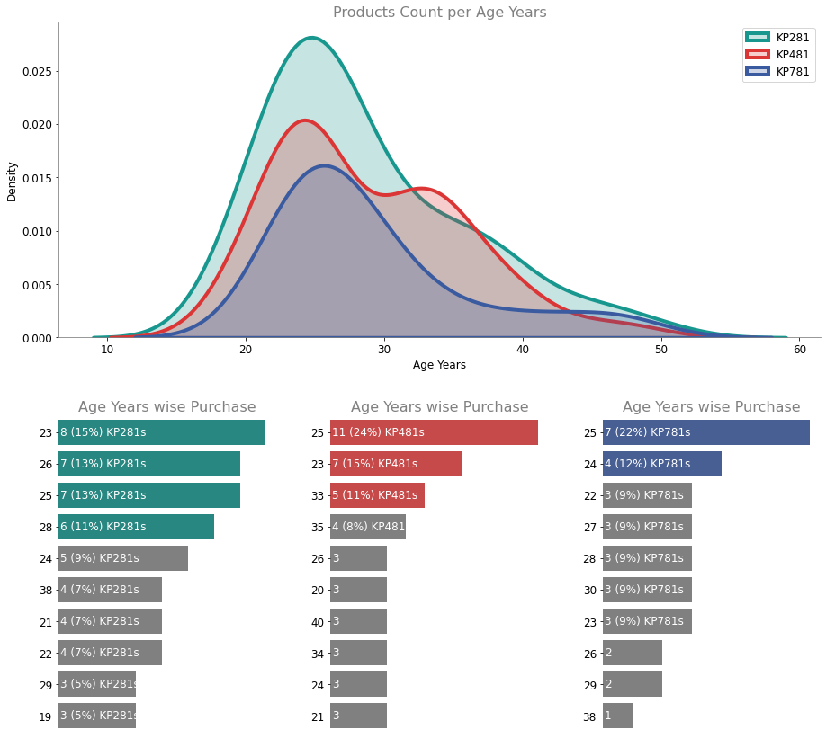

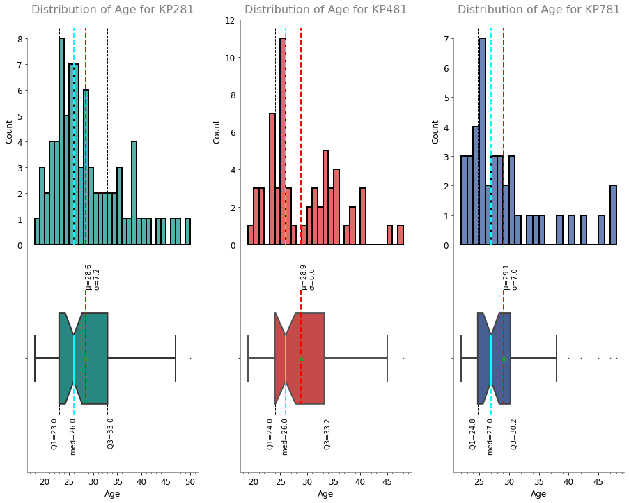

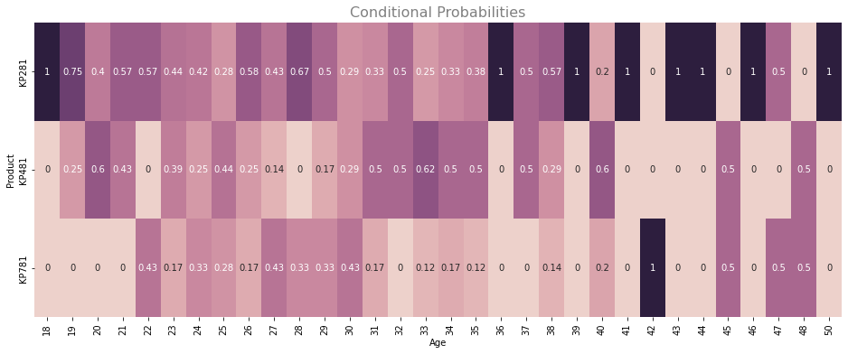

```python
product_wise_plots(df_=df, var_='Age', main_title='Products Count per Age Years', xlablel_='Age Years', title_='Age Years wise Purchase', box_major=[5]*3, box_minor=[1]*3)
```

**Insights**:

**Recommendation**:

## Education

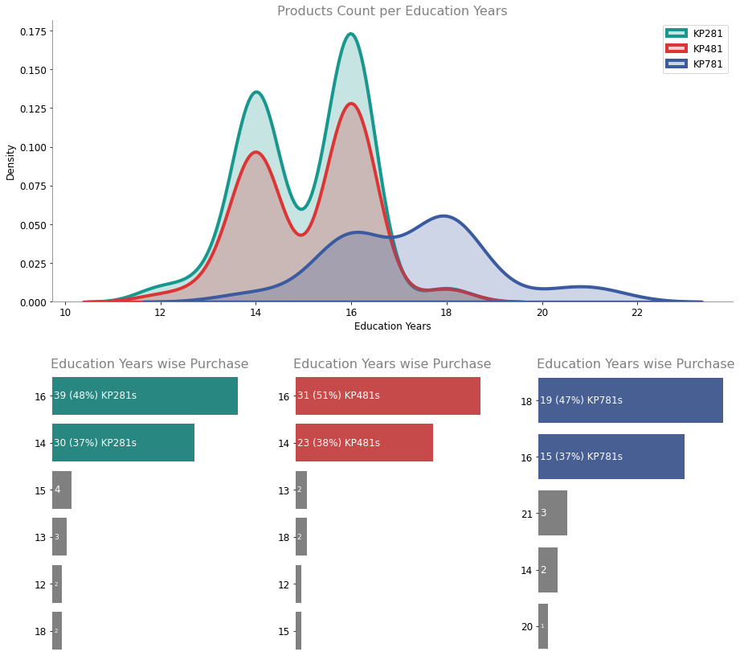

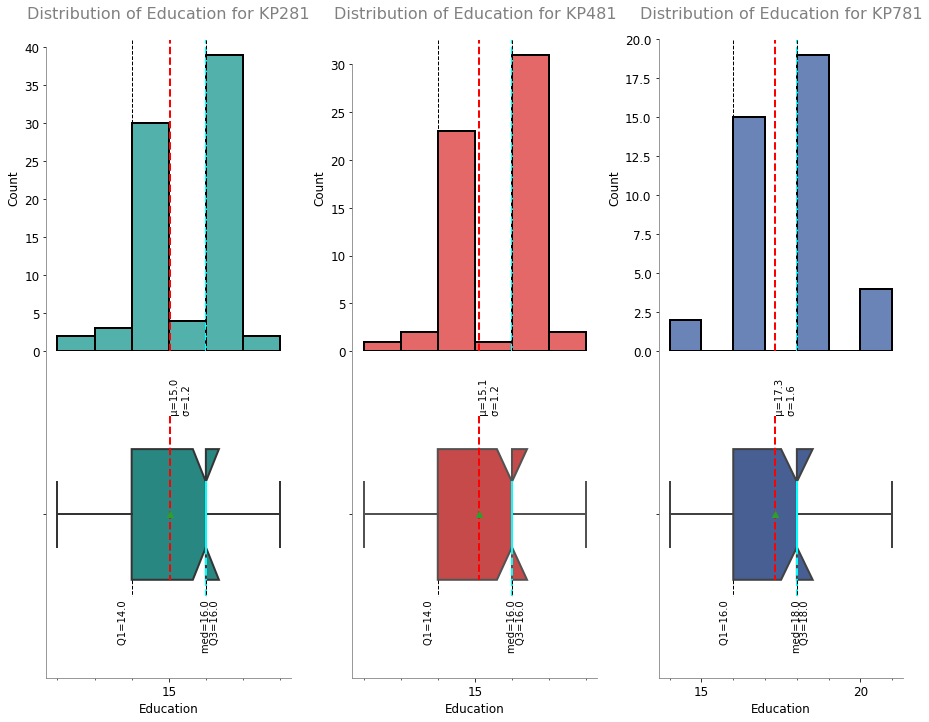

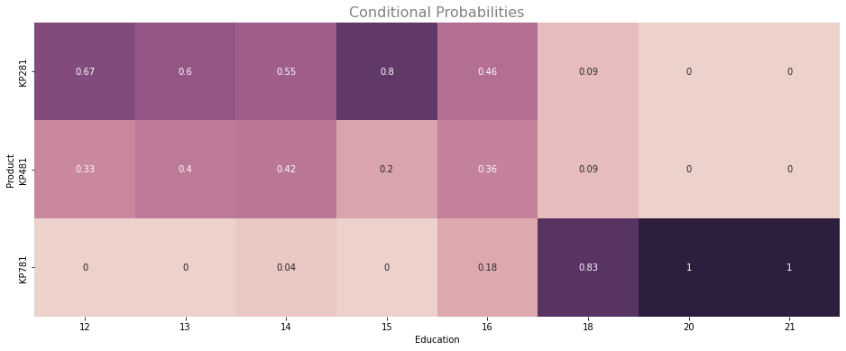

```python
product_wise_plots(df_=df, var_='Education', main_title='Products Count per Education Years', xlablel_='Education Years', title_='Education Years wise Purchase', box_major=[5]*3, box_minor=[1]*3)
```

**Insights**:

- Regardless of years of education, customers most preferred KP281, followed by KP481, and finally KP781. However, highly educated customers (with an education level of more than 18 years) were more likely to buy KP781 than other products

**Recommendation**:

- To a highly educated customer, we should recommend KP781

## Income

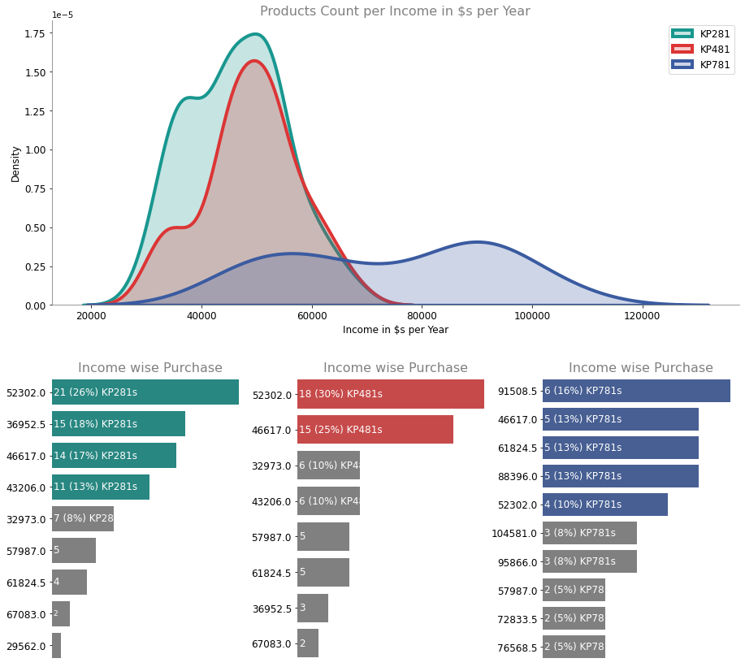

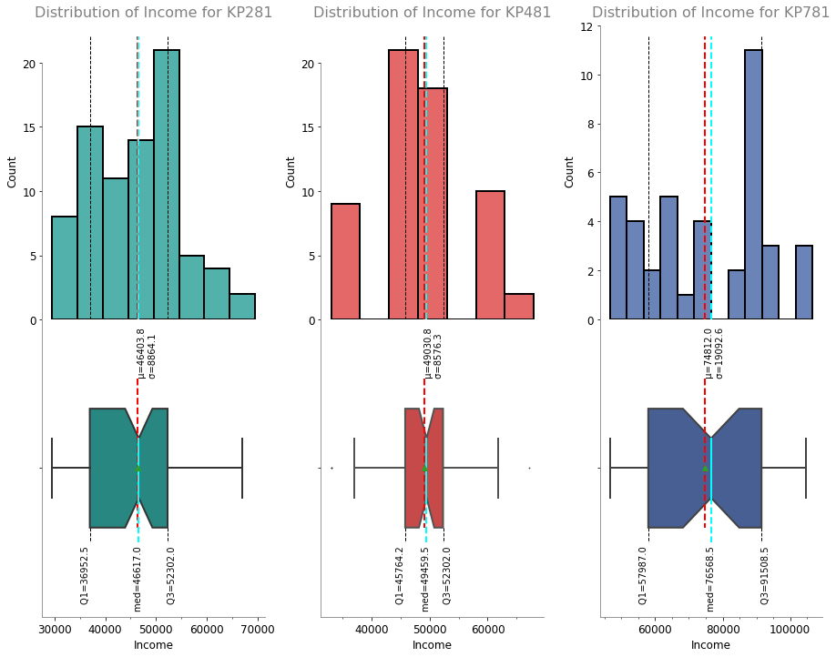

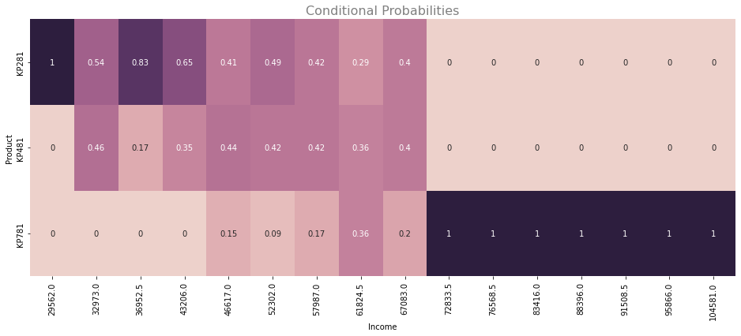

```python
product_wise_plots(df_=df, var_='Income', main_title='Products Count per Income in $s per Year', xlablel_='Income in $s per Year', title_='Income wise Purchase', box_major=[10000]*2+[20000], box_minor=[5000]*3)
```

**Insights**:

- Low-income customers (income of less than \$45,000 per year) preferred KP281.
- Middle-income customers (income between \$45,000 and \$70,000 per year) equally preferred KP281 and KP481.
- High-income customers (income of more than \$70,000 per year) preferred only KP781.

**Recommendation**:

- A low-income customer (income less than \$45,000 per year) should be recommended KP281
- To a high income customers (income over \$70,000 per year) we should recommend KP781

## Fitness

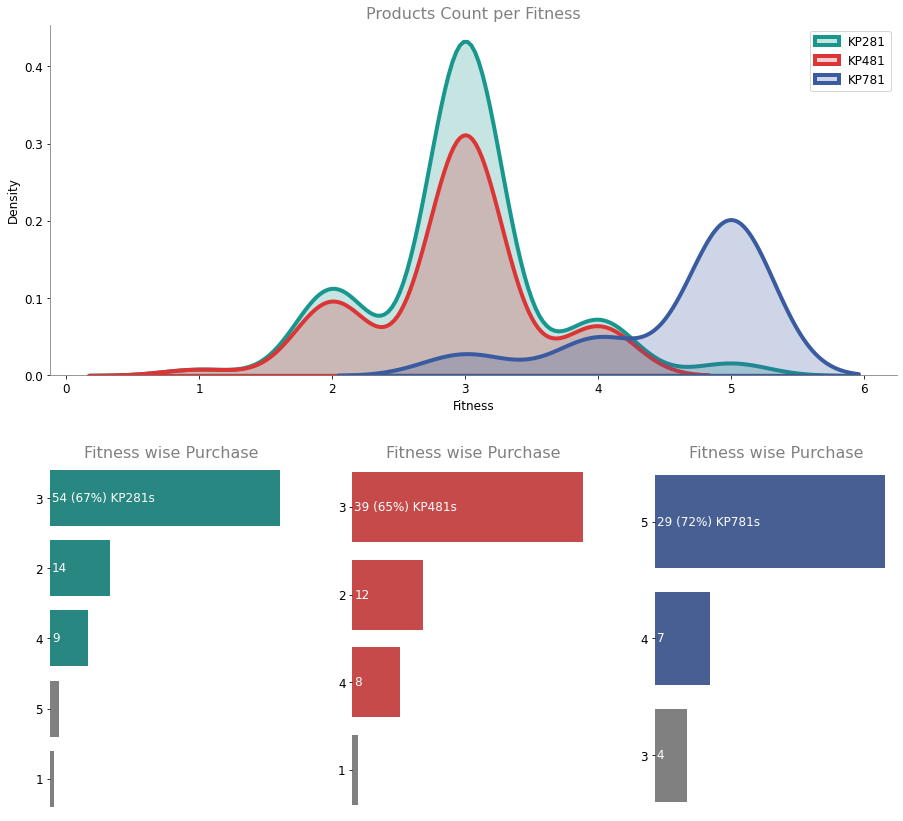

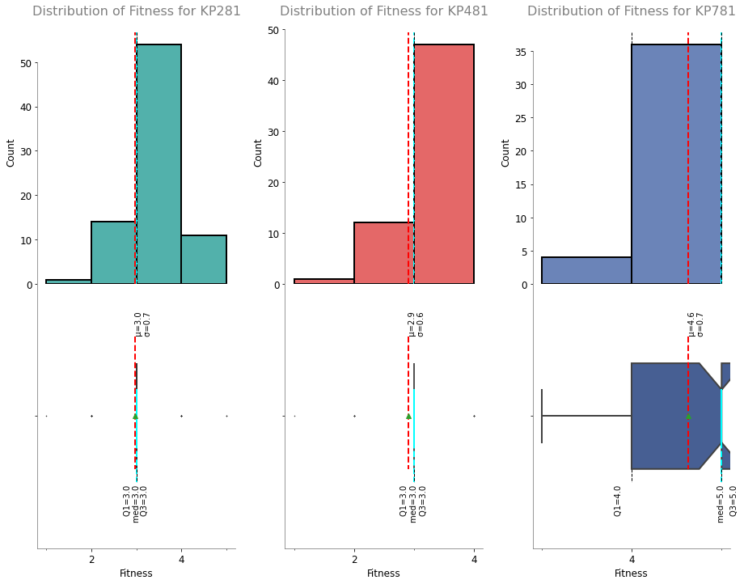

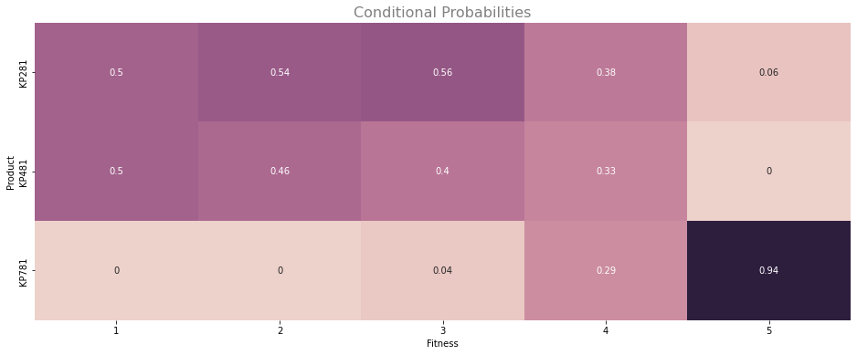

```python
product_wise_plots(df_=df, var_='Fitness', main_title='Products Count per Fitness', xlablel_='Fitness', title_='Fitness wise Purchase', box_major=[2]*3, box_minor=[1]*3)
```

**Insights**:

- Customers with average fitness levels (fitness level less than 4) preferred KP281 and KP481 equally
- Healthier customers (fitness level 4) had no preference
- Health-conscious customers who are already in good shape (fitness level 5) preferred KP781 over others

**Recommendation**:

- Customers with average fitness levels (fitness level below 4) should be recommended either KP281 or KP481
- To customers who are already in very good fitness shape (fitness level 5) we should recommend KP781

## Usage

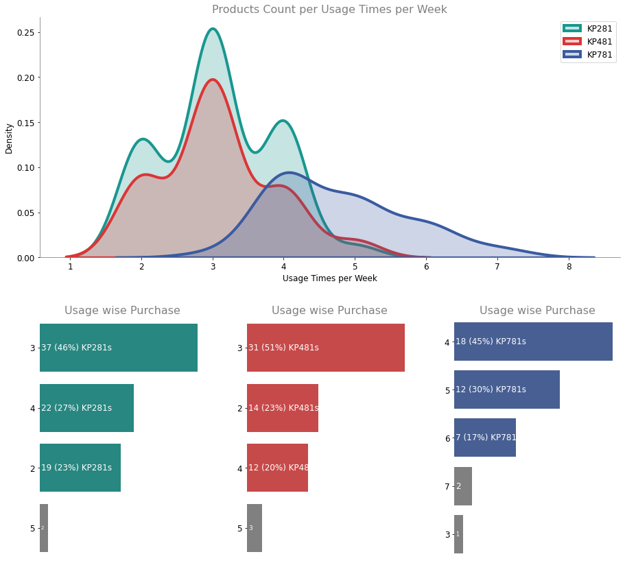

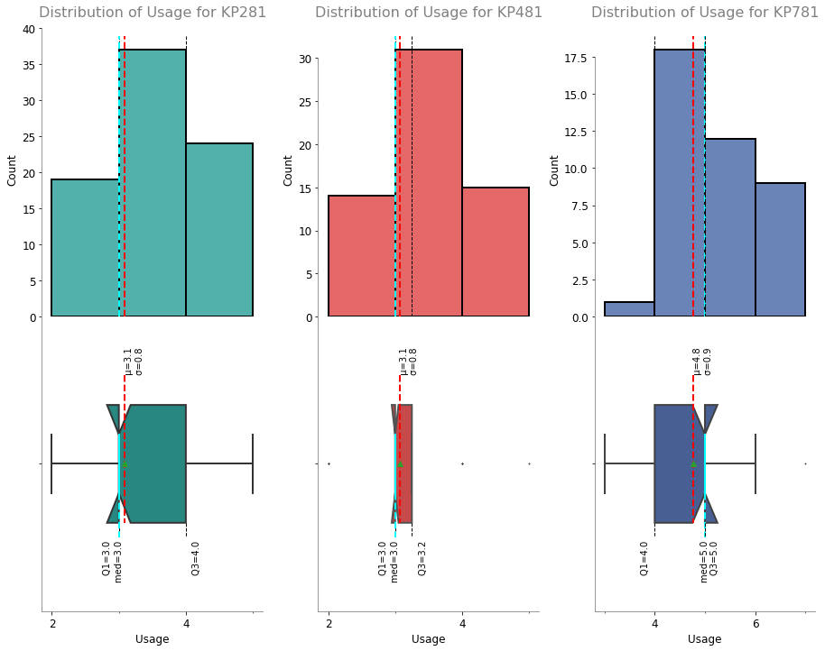

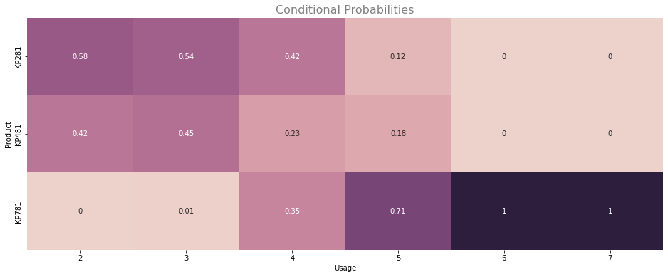

```python
product_wise_plots(df_=df, var_='Usage', main_title='Products Count per Usage Times per Week', xlablel_='Usage Times per Week', title_='Usage wise Purchase', box_major=[2]*3, box_minor=[1]*3)
```

**Insights**:

- Customers who plan to use the treadmill less than 4 days per week preferred KP281, followed by the KP481
- Customers who plan to use the treadmill 4 days per week prefer different machines
- Customers who plan to use the treadmill more than 4 days per week mostly preferred KP781

**Recommendation**:

- Customers who plan to use the treadmill less than 4 days per week should be recommended either KP281 or KP481
- To customers who plan to use the treadmill more than 4 days per week, we should recommend KP781

## Miles

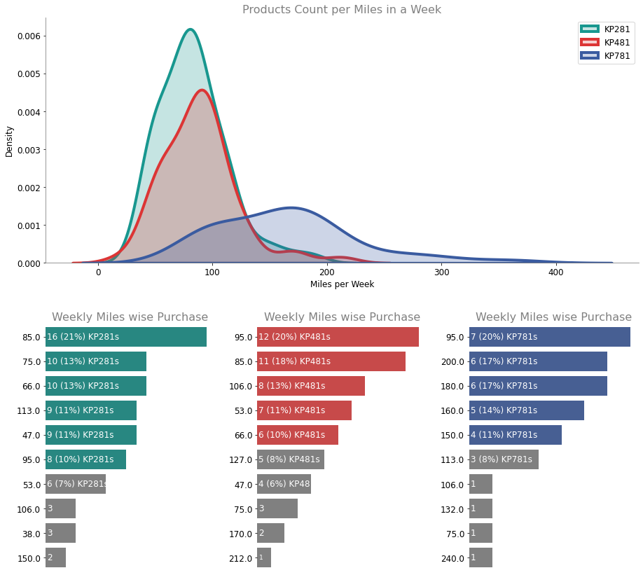

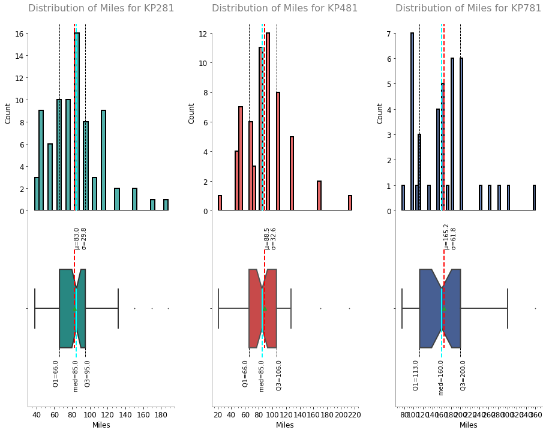

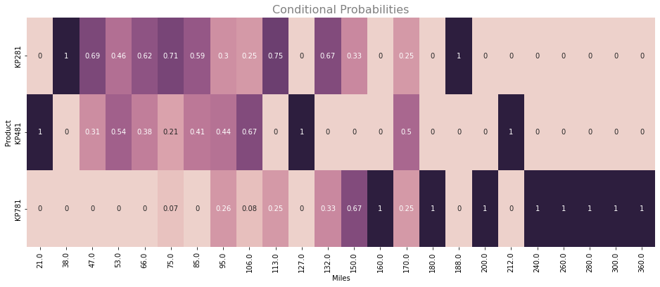

```python
product_wise_plots(df_=df, var_='Miles', main_title='Products Count per Miles in a Week', xlablel_='Miles per Week', title_='Weekly Miles wise Purchase', box_major=[20]*3, box_minor=[5]*3)
```

**Insights**:

**Recommendation**:

# Business Recommendations